# SKA analysis BCO/APEC

Max Cummins

2023-04-10

# Outline

Here I will document the processing of SKA-borne SNP data for the investigation of relatedness between APEC samples from cases of BCO vs colibacillosis.

First lets read in our datasets. We will also do some data processing to join tables:

```r
#Read in SNP distances
dists <- read_delim("analysis/ska/AVC_FH.distances.tsv",
    delim = "\t", escape_double = FALSE,
    trim_ws = TRUE, show_col_types = FALSE)

#Read in SNP Clusters
clusts <- read_delim("analysis/ska/AVC_FH.clusters.tsv",
    delim = "\t", escape_double = FALSE,
    trim_ws = TRUE, show_col_types = FALSE)

#Read in MLST data
mlst <- read_delim(
    "analysis/mlst.txt",
    delim = "\t",
    escape_double = FALSE,
    trim_ws = TRUE,
    show_col_types = FALSE
)

#Read in the list of genomes which passed QC
QC_pass <- read_csv("delims/QC_pass.txt", col_names = "name", show_col_types = FALSE)

#Read in our metadata
metadata <- read_delim("delims/merged_metadata_AVC_FH.txt", delim = "\t", show_col_types = FALSE)

#Define paths for genotypic data
pointfinder_path <- "analysis/pointfinder.txt"
pMLST_path <- "analysis/pMLST.txt"
abricate_path <- "analysis/genotype.txt"

output_name <- "APEC_BCO"

#Filter out samples which didnt pass QC
mlst <- mlst %>% filter(name %in% QC_pass$name)

#Filter out samples which didnt pass QC
metadata <- metadata %>% filter(`Sample Name` %in% QC_pass$name)

#Read in our cgMLST data
enterobase_data <- read_delim("delims/enterobase.txt", delim = "\t", show_col_types = FALSE)

#Rename name column
metadata <- metadata %>% rename('name' = 'Sample Name')

##NEED TO FIX THIS STEP
metadata <- enterobase_data %>% rename(name = "Name") %>% dplyr::select(name, starts_with("HC"), `fimH (fimTyper)(Phylotypes)`) %>% right_join(metadata, by = "name") %>% rename("fimtype" = `fimH (fimTyper)(Phylotypes)`)

#Fix the source column for internal isolates
metadata <- metadata %>% rename("ID" = `name`)

#Remove duplicates - not sure why theyre in there
metadata <- metadata %>% unique

#Combine our metadata and our clusters for use in microreact
data_microreact <- left_join(clusts, metadata, by = "ID") #, by.x = "ID", by.y = "name")

#Combine our ST data and metadata/clusters for use in microreact
data_microreact <- mlst %>% dplyr::select(name, ST) %>% rename("ID" = name) %>% right_join(data_microreact, by = "ID")

data_microreact <- data_microreact %>% filter(ID %in% clusts$ID)

#Write this to file
write_delim(x = data_microreact, file = "analysis/ska/AVC_FH.clusters_w_metadata.tsv", delim = "\t")

data_microreact1 <- data_microreact %>% rename("Sample 1" = "ID") %>% rev()

data_microreact2 <- data_microreact %>% rename("Sample 2" = "ID")

dists2 <- inner_join(data_microreact1, dists, by = "Sample 1")
dists2 <- inner_join(dists2, data_microreact2, by = "Sample 2")

dists3 <- dists2 %>% filter(SNPs < 1000)

#dists3 %>% filter(Cluster__autocolour.x == Cluster__autocolour.y) %>% filter(Bird_Gross_Necropsy_ID.x == Bird_Gross_Necropsy_ID.x) %>% arrange(Bird_Gross_Necropsy_ID.x, SNPs) %>% drop_na(QC_Pass.x, QC_Pass.y) %>% View()
```

## Generate SKA figures

Now we will read in our tree as this will help us to filter out any unwanted samples which didnt pass QC.

We will then visualise the SNP distances between the strains which share an ST and are of STs 117, 57 or 95. This is because the sample sizes for these STs is quite high, aiding visualisation of the distances between these strains. Below a dotted red line indicates a cut-off of 100 SNPs which we deem closely related. Three panels below highlight comparisons across collections, within the colibac collection and within the BCO collection.

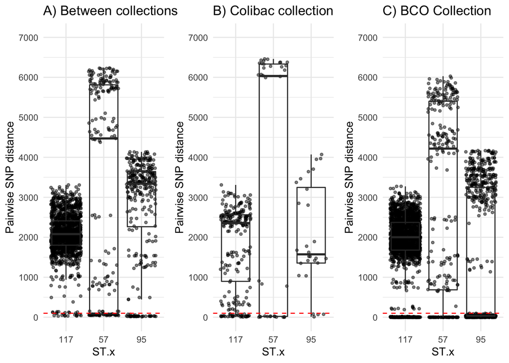

```r
tree_path <- "analysis/trees/old/mashtree_QC_pass.tree"#"analysis/trees/old/mashtree_QC_pass_AVC_BCO_bone_nondup.tree"

tree <- read.tree(tree_path)

tree$tip.label <- gsub(".R1$", "", tree$tip.label)

birds_w_many_sites <- metadata %>% group_by(Bird_Gross_Necropsy_ID) %>% tally() %>% filter(n > 4) %>% arrange(desc(n)) %>% dplyr::select(Bird_Gross_Necropsy_ID)

samples_per_bird <- metadata %>% filter(grepl("FH", ID)) %>% filter(ID %in% QC_pass$name) %>% group_by(Bird_Gross_Necropsy_ID) %>% summarise(samples = n())


#dists2 %>% filter(`Sample 1` %in% tree$tip.label) %>% filter(`Sample 2` %in% tree$tip.label)

df_all_ST_filtered_SNPs <- dists2 %>% as.data.frame() %>% filter(ST.x == ST.y)

cross_collection <- df_all_ST_filtered_SNPs %>%
        filter(Collection.x != Collection.y) %>%
        #filter(Bird_Gross_Necropsy_ID.x == Bird_Gross_Necropsy_ID.y) %>%
        filter(ST.x %in% c(117, 95, 57)) %>%
        #filter(SNPs < 10) %>%
        ggplot(aes(x = ST.x, y = SNPs)) +
        #facet_wrap(~ Bird_Gross_Necropsy_ID.x + Bird_Gross_Necropsy_ID.y) +
        geom_jitter(height = 0, alpha = 0.5, size = 1) +
        geom_boxplot(alpha = 0) +
        scale_y_continuous(name = "Pairwise SNP distance",
                           limits = c(0, 7000),
                           breaks = c(seq(from = 0,
                                          to = 7000,
                                          by = 1000))) +
        ggtitle("A) Between collections") +
        #scale_color_manual(values = source_combo_cols) +
        #scale_x_discrete(name = "Sequence Type", limits=x_order_ww) +
        geom_hline(yintercept = 100, color = "red", linetype = "dashed") +
        theme_minimal() +
        guides(colour = guide_legend(override.aes = list(size=6)))

AVC_collection <- df_all_ST_filtered_SNPs %>%
        filter(Collection.x == Collection.y & Collection.x == "AVC") %>%
        #filter(Bird_Gross_Necropsy_ID.x == Bird_Gross_Necropsy_ID.y) %>%
        filter(ST.x %in% c(117, 95, 57)) %>%
        #filter(SNPs < 10) %>%
        ggplot(aes(x = ST.x, y = SNPs)) +
        #facet_wrap(~ Bird_Gross_Necropsy_ID.x + Bird_Gross_Necropsy_ID.y) +
        geom_jitter(height = 0, alpha = 0.5, size = 1) +
        geom_boxplot(alpha = 0) +
        scale_y_continuous(name = "Pairwise SNP distance",
                           limits = c(0, 7000),
                           breaks = c(seq(from = 0,
                                          to = 7000,
                                          by = 1000))) +
        ggtitle("B) Colibac collection") +
        #scale_color_manual(values = source_combo_cols) +
        #scale_x_discrete(name = "Sequence Type", limits=x_order_ww) +
        geom_hline(yintercept = 100, color = "red", linetype = "dashed") +
        theme_minimal() +
        guides(colour = guide_legend(override.aes = list(size=6)))

BCO_collection <- df_all_ST_filtered_SNPs %>%
        filter(Collection.x == Collection.y & Collection.x == "BCO")  %>%
        #filter(Bird_Gross_Necropsy_ID.x == Bird_Gross_Necropsy_ID.y) %>%
        filter(ST.x %in% c(117, 95, 57)) %>%
        #filter(SNPs < 10) %>%
        ggplot(aes(x = ST.x, y = SNPs)) +
        #facet_wrap(~ Bird_Gross_Necropsy_ID.x + Bird_Gross_Necropsy_ID.y) +
        geom_jitter(height = 0, alpha = 0.5, size = 1) +
        geom_boxplot(alpha = 0) +
        scale_y_continuous(name = "Pairwise SNP distance",
                           limits = c(0, 7000),
                           breaks = c(seq(from = 0,
                                          to = 7000,
                                          by = 1000))) +
        ggtitle("C) BCO Collection") +
        #scale_color_manual(values = source_combo_cols) +
        #scale_x_discrete(name = "Sequence Type", limits=x_order_ww) +
        geom_hline(yintercept = 100, color = "red", linetype = "dashed") +
        theme_minimal() +
        guides(colour = guide_legend(override.aes = list(size=6)))

grid.arrange(cross_collection, AVC_collection, BCO_collection, nrow = 1)
```

Lets generate the same figure again but this time with a bit of colour to differentiate the STs.

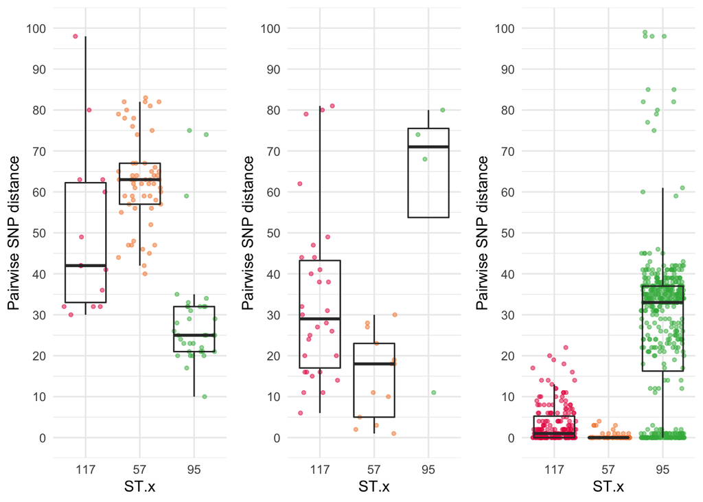

```r
cross_collection <- df_all_ST_filtered_SNPs %>% filter(SNPs <= 100) %>%
        filter(Collection.x != Collection.y) %>%
        #filter(Bird_Gross_Necropsy_ID.x == Bird_Gross_Necropsy_ID.y) %>%
        filter(ST.x %in% c(117, 95, 57)) %>%
        #filter(SNPs < 10) %>%
        ggplot(aes(x = ST.x, y = SNPs)) +
        #facet_wrap(~ Bird_Gross_Necropsy_ID.x + Bird_Gross_Necropsy_ID.y) +
        geom_jitter(height = 0, alpha = 0.5, size = 1, aes(color = ST.x)) +
        geom_boxplot(alpha = 0) +
        scale_y_continuous(name = "Pairwise SNP distance",
                           limits = c(0, 100),
                           breaks = c(seq(from = 0,
                                          to = 100,
                                          by = 10))) +
        #ggtitle("C) BCO Collection") +
        scale_color_manual(values = c("#e6194B", "#f58231", "#3cb44b")) +
        #scale_x_discrete(name = "Sequence Type", limits=x_order_ww) +
        #geom_hline(yintercept = 100, color = "red", linetype = "dashed") +
        theme_minimal() +
        guides(color="none")

AVC_collection <- df_all_ST_filtered_SNPs %>% filter(SNPs <= 100) %>%
        filter(Collection.x == Collection.y & Collection.x == "AVC") %>%
        #filter(Bird_Gross_Necropsy_ID.x == Bird_Gross_Necropsy_ID.y) %>%
        filter(ST.x %in% c(117, 95, 57)) %>%
        #filter(SNPs < 10) %>%
        ggplot(aes(x = ST.x, y = SNPs)) +
        #facet_wrap(~ Bird_Gross_Necropsy_ID.x + Bird_Gross_Necropsy_ID.y) +
        geom_jitter(height = 0, alpha = 0.5, size = 1, aes(color = ST.x)) +
        geom_boxplot(alpha = 0) +
        scale_y_continuous(name = "Pairwise SNP distance",
                           limits = c(0, 100),
                           breaks = c(seq(from = 0,
                                          to = 100,
                                          by = 10))) +
        #ggtitle("C) BCO Collection") +
        scale_color_manual(values = c("#e6194B", "#f58231", "#3cb44b")) +
        #scale_x_discrete(name = "Sequence Type", limits=x_order_ww) +
        #geom_hline(yintercept = 100, color = "red", linetype = "dashed") +
        theme_minimal() +
        guides(color="none")

BCO_collection <- df_all_ST_filtered_SNPs %>% filter(SNPs <= 100) %>%
        filter(Collection.x == Collection.y & Collection.x == "BCO")  %>%
        #filter(Bird_Gross_Necropsy_ID.x == Bird_Gross_Necropsy_ID.y) %>%
        filter(ST.x %in% c(117, 95, 57)) %>%
        #filter(SNPs < 10) %>%
        ggplot(aes(x = ST.x, y = SNPs)) +
        #facet_wrap(~ Bird_Gross_Necropsy_ID.x + Bird_Gross_Necropsy_ID.y) +
        geom_jitter(height = 0, alpha = 0.5, size = 1, aes(color = ST.x)) +
        geom_boxplot(alpha = 0) +
        scale_y_continuous(name = "Pairwise SNP distance",
                           limits = c(0, 100),
                           breaks = c(seq(from = 0,
                                          to = 100,
                                          by = 10))) +
        #ggtitle("C) BCO Collection") +
        scale_color_manual(values = c("#e6194B", "#f58231", "#3cb44b")) +
        #scale_x_discrete(name = "Sequence Type", limits=x_order_ww) +
        #geom_hline(yintercept = 100, color = "red", linetype = "dashed") +
        theme_minimal() +
        guides(color="none")

grid.arrange(cross_collection, AVC_collection, BCO_collection, nrow = 1)
```

## Check cgMLST and SKA concordance

We now want to check that all genomes which share an ST and are below 100 SNPs have a reasonable closeness by cgmlst data.

```r
name1 <- df_all_ST_filtered_SNPs %>% pull(`Sample 1`)
name2 <- df_all_ST_filtered_SNPs %>% pull(`Sample 2`)
name3 <- c(name1, name2)


#All hit at HC10, 379/1195
check_me_for_HC10_proof <- dists %>% filter(`Sample 1` %in% name3 & `Sample 2` %in% name3) %>%
    inner_join(mlst[,c(1,3)], by = c("Sample 1" = "name")) %>%
    rename("ST_1" = ST) %>%
    inner_join(mlst[,c(1,3)], by = c("Sample 2" = "name")) %>%
    rename("ST_2" = ST)  %>%
    inner_join(metadata[,c(1,5)], by = c("Sample 1" = "ID")) %>%
    rename_at(vars(starts_with('HC')), funs(paste0('Sample1', .))) %>%
    inner_join(metadata[,c(1,5)], by = c("Sample 2" = "ID")) %>%
    rename_at(vars(starts_with('HC')), funs(paste0('Sample2', .))) %>%
    filter(ST_1 == ST_2) %>%
    mutate(same_HC10 = `Sample1HC10(cgMLST V1 + HierCC V1)` == `Sample2HC10(cgMLST V1 + HierCC V1)`) %>%
    filter(SNPs <= 100) %>% group_by(same_HC10) %>% tally()

#All hit at HC20, 443/664
check_me_for_HC20_proof <- dists %>% filter(`Sample 1` %in% name3 & `Sample 2` %in% name3) %>%
    inner_join(mlst[,c(1,3)], by = c("Sample 1" = "name")) %>%
    rename("ST_1" = ST) %>%
    inner_join(mlst[,c(1,3)], by = c("Sample 2" = "name")) %>%
    rename("ST_2" = ST)  %>%
    inner_join(metadata[,c(1,6)], by = c("Sample 1" = "ID")) %>%
    rename_at(vars(starts_with('HC')), funs(paste0('Sample1', .))) %>%
    inner_join(metadata[,c(1,6)], by = c("Sample 2" = "ID")) %>%
    rename_at(vars(starts_with('HC')), funs(paste0('Sample2', .))) %>%
    filter(ST_1 == ST_2) %>%
    mutate(same_HC20 = `Sample1HC20(cgMLST V1 + HierCC V1)` == `Sample2HC20(cgMLST V1 + HierCC V1)`) %>%
    filter(SNPs <= 100) %>% group_by(same_HC20) %>% tally()
```

Lets first see how many share an HC10 group:

```r
knitr::kable(check_me_for_HC10_proof, align = 'c')
```

| same_HC10 | n |
| --- | --- |
| FALSE | 379 |
| TRUE | 816 |

And now how many share an HC20 group:

```r
knitr::kable(check_me_for_HC20_proof, align = 'c')
```

| same_HC20 | n |
| --- | --- |
| FALSE | 84 |
| TRUE | 1111 |

Clearly the vast majority of samples under 100 SNPs we are analysing share an HC20, giving us extra confidence in our methodology.

## ColV analysis

Lets now briefly explore how many SNPs apart strains from the same birds are:

```r
within_bird <- df_all_ST_filtered_SNPs %>%
        filter(Collection.x == "BCO")  %>%
        filter(Bird_Gross_Necropsy_ID.x == Bird_Gross_Necropsy_ID.y) %>%
        filter(ST.x == ST.y) %>%
        #filter(SNPs < 10) %>%
        ggplot(aes(x = Collection.x, y = SNPs)) +
        #facet_wrap(~ Bird_Gross_Necropsy_ID.x + Bird_Gross_Necropsy_ID.y) +
        geom_jitter(height = 0, alpha = 0.5, size = 1) +
        geom_boxplot(alpha = 0) +
        scale_y_continuous(name = "Pairwise SNP distance",
                           limits = c(0, 10),
                           breaks = c(seq(from = 0,
                                          to = 10,
                                          by = 1))) +
        #ggtitle("C) BCO Collection") +
        scale_color_manual(values = c("#e6194B", "#f58231", "#3cb44b")) +
        #scale_x_discrete(name = "Sequence Type", limits=x_order_ww) +
        #geom_hline(yintercept = 100, color = "red", linetype = "dashed") +
        theme_minimal() +
        guides(color="none")

table_for_plotting <- df_all_ST_filtered_SNPs %>%
        filter(Collection.x == "BCO")  %>%
        filter(Bird_Gross_Necropsy_ID.x == Bird_Gross_Necropsy_ID.y) %>%
        filter(ST.x == ST.y) %>%
        group_by(SNPs) %>%
        tally(sort = T) %>%
        mutate(perc = scales::percent(n/sum(.$n)))

knitr::kable(table_for_plotting, align = 'c')
```

| SNPs | n | perc |
| --- | --- | --- |
| 0 | 175 | 70.0% |
| 1 | 46 | 18.4% |
| 2 | 18 | 7.2% |
| 3 | 7 | 2.8% |
| 9 | 2 | 0.8% |
| 6 | 1 | 0.4% |
| 45 | 1 | 0.4% |

Lastly lets explore the relationship between ColV carriage and collection. Is there a statistically significant difference btween carriage of ColV plasmids between APEC which cause BCO and those associated with colibacillosis?

```r
#Run AbricateR to summarise genomic data
abricateR::abricateR(
        abricate_in = abricate_path,
        output = output_name,
        output_directory = output_dir,
        identity = 90,
        length = 90,
        writecsv = FALSE,
        pointfinder_data = pointfinder_path
)

geno <- APEC_BCO_simple_summary_N90L90 %>% filter(name %in% tree$tip.label)

genometa <- metadata %>% rename("name" = "ID") %>% inner_join(geno)

ColV_by_Collec <- table(genometa$ColV, genometa$Collection)

rownames(ColV_by_Collec) <- c("ColV Neg", "ColV Positive")

chisq.test(ColV_by_Collec, correct = FALSE)
```

```
##
##  Pearson's Chi-squared test
##
## data:  ColV_by_Collec
## X-squared = 3.8571, df = 1, p-value = 0.04953
```